# The AMP-AD Wall Of Targets

Lara Mangravite, Ben Logsdon, Kenneth Daily

2017-07-11

[figure not shown]

## Goal

Create a visual dashboard and integrative analysis platform that provides consistent and robust supporting evidence for use in:

- Prioritization of targets nominated by individual AMP-AD projects.
- Nomination of targets supported across AMP-AD projects.
- Compilation of AMP-AD evidence for use by research community to evaluate other targets of interest.

## Approach

1. Develop prototype.
2. Build alpha platform based on user feedback, focusing on gene-based queries for nominated AMP-AD targets.
3. Expand to include genes across the genome (partnership with Josh Shulman @ Baylor).
4. Expand to provide entry points based on gene, protein, network, or variant queries.

> **Anticipated users:** AMP-AD consortium and affiliates, MODEL-AD consortium, external AD researchers

## Enhancing AMP-AD Project R01

Increasing resources for target prioritization  
within the AMP-AD community

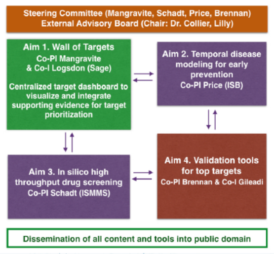

## User experience interviews

> Understand how our users will interact and utilize the Wall of Targets application - usages, pain points, gaps, and preferences.

> Performed **think aloud exercise** - use the application and state what you are doing and what you are thinking as you use the prototype.

> 10 participants, including 4 industry/pharma and 3 mouse model system researchers

## Version 0, main page

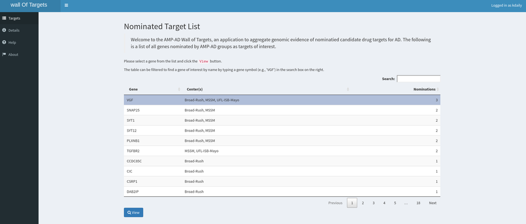

## Version 0, detail page

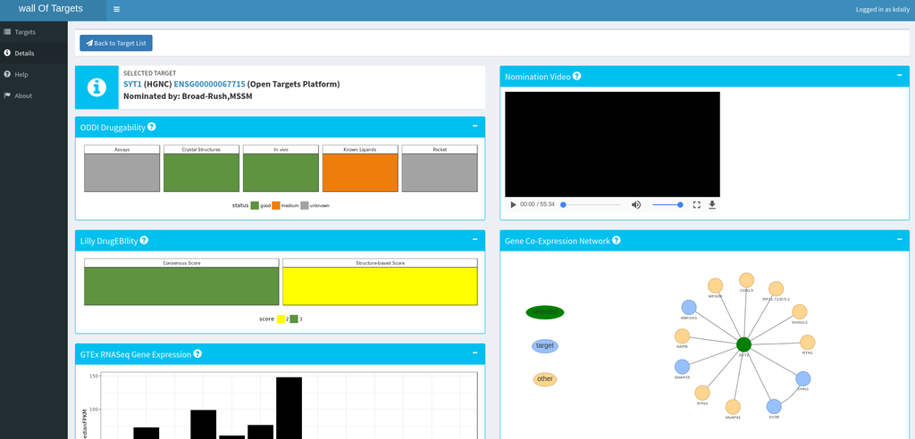

## Interviews - what we learned

1. Biological context
2. Druggability vs. tractability
3. Nominations and source of evidence
4. Consistency and reproducibility across cohorts
5. Ranking and comparison

## Main page, alpha version

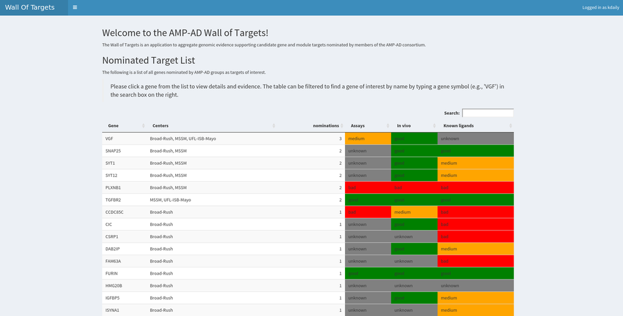

> Includes overview of evidence for indication of strength of target (future: include ranking).

## Details page, alpha version

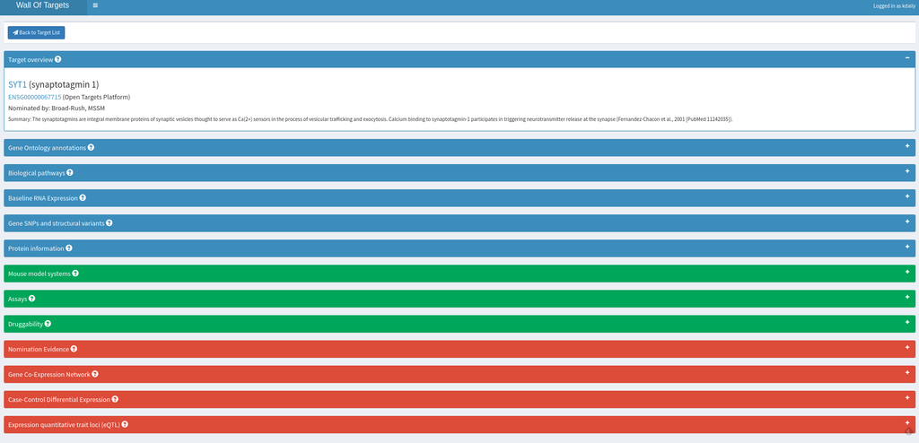

> Condensed layout including biological context.

## Details page, alpha version

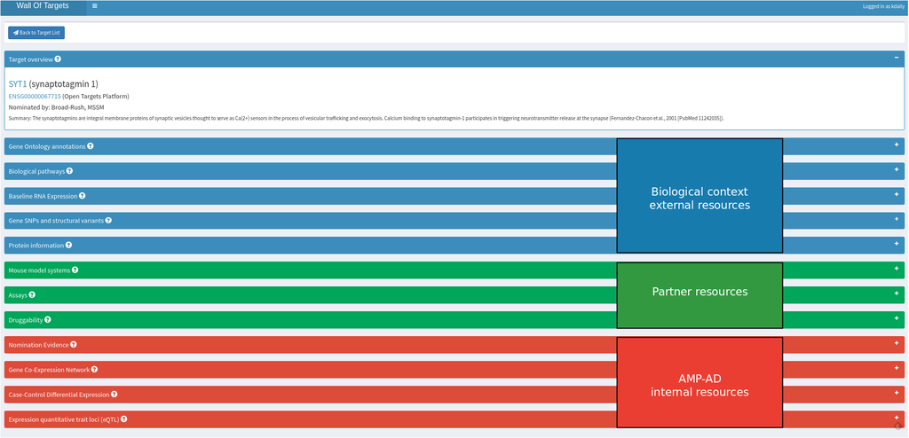

> Indication of data sources.

## Gene Ontology terms, alpha version

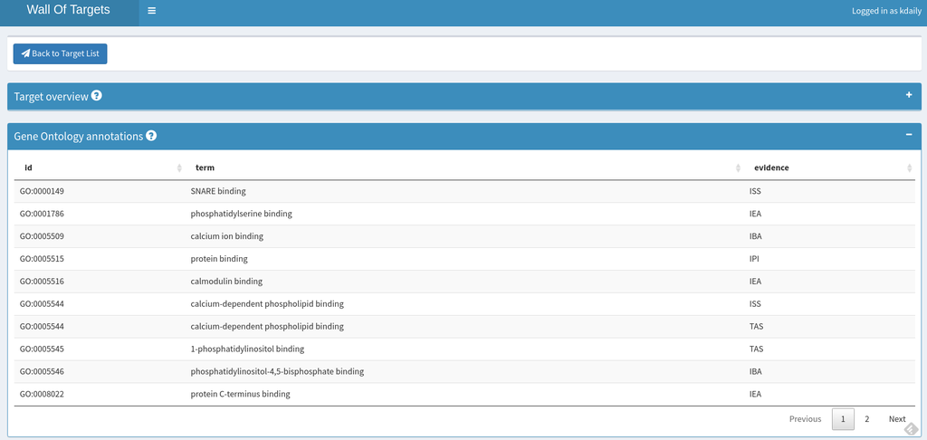

## Biological pathways, alpha version

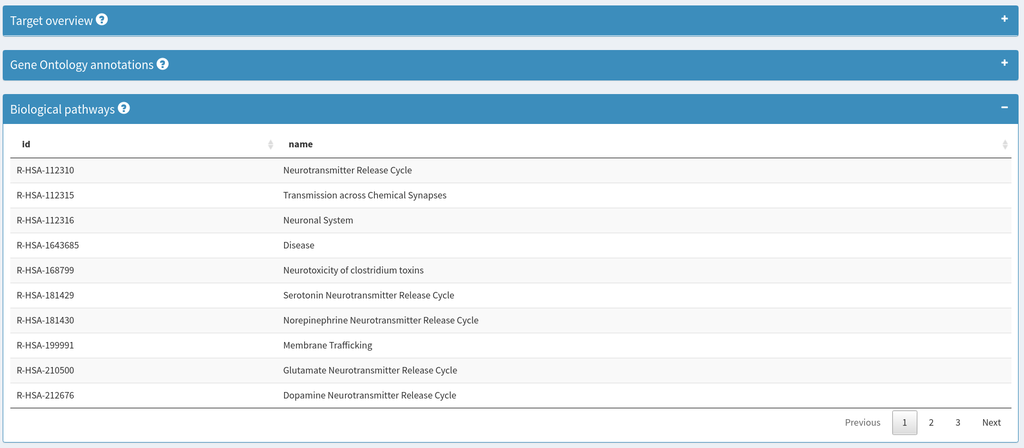

## Mouse models, alpha version

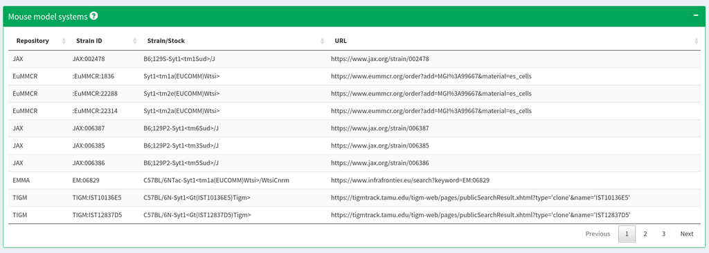

## Baseline RNA Expression, alpha version

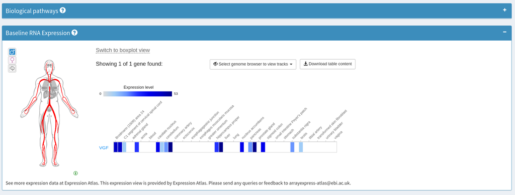

> Expression from more sources and outside of brain.

## Nomination evidence, alpha version

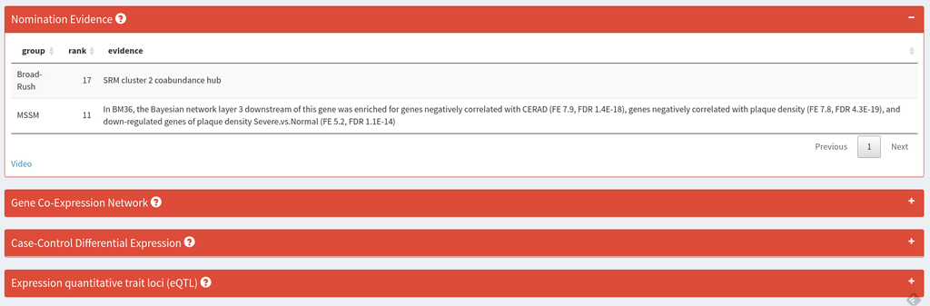

> Show evidence from nominating center(s).

## Other data sources, alpha version

[figure not shown]